# exercise-11_challenge2

SLCornett

4/14/2022

# Challenge 2

```r
library(tidyverse) #always necessary
```

```r
library(tidyr)
library(dplyr)
library(ggplot2)
library(ggpubr)
library(skimr)
library(broom)
library(infer)
library(mosaic)
```

## One-Factor ANOVA and Inference

A. Load the AVONET dataset

```r
f <- "https://raw.githubusercontent.com/difiore/ada-2022-datasets/main/AVONETdataset1.csv"
d1 <- read_csv(f, col_names = TRUE)
```

B. Filter the dataset to include only the following variables (19 total): Species1, Family1, Order1, Beak.Length_Culmen, Beak.Width, Beak.Depth, Tarsus.Length, Wing.Length, Tail.Length, Mass, Habitat, Migration, Trophic.Level, Trophic.Niche, Min.Latitude, Max.Latitude, Centroid.Latitude, Primary.Lifestyle, and Range.Size

```r
#selecting specific variables
d1 <- d1 %>%
  select(Species1,
         Family1,
         Order1,
         Beak.Length_Culmen, #added 12/4/22
         Beak.Width,
         Beak.Depth,
         Tarsus.Length,
         Wing.Length,
         Tail.Length,
         Mass,
         Habitat,
         Migration,
         Trophic.Level,
         Trophic.Niche,
         Primary.Lifestyle, #added 12/4/22
         Min.Latitude,
         Max.Latitude,
         Centroid.Latitude,
         Range.Size)
head(d1) # heck the selection worked
```

```
## # A tibble: 6 × 19
##   Species1   Family1 Order1 Beak.Length_Cul… Beak.Width Beak.Depth Tarsus.Length
##   <chr>      <chr>   <chr>             <dbl>      <dbl>      <dbl>         <dbl>
## 1 Accipiter… Accipi… Accip…             27.7       10.6       14.7          62
## 2 Accipiter… Accipi… Accip…             20.6        8.8       11.6          43
## 3 Accipiter… Accipi… Accip…             25          8.6       12.7          58.1
## 4 Accipiter… Accipi… Accip…             22.5        8.9       11.9          61.2
## 5 Accipiter… Accipi… Accip…             21.1        8.7       11.1          46.4
## 6 Accipiter… Accipi… Accip…             20          6.6       12            48.7
## # … with 12 more variables: Wing.Length <dbl>, Tail.Length <dbl>, Mass <dbl>,
## #   Habitat <chr>, Migration <dbl>, Trophic.Level <chr>, Trophic.Niche <chr>,
## #   Primary.Lifestyle <chr>, Min.Latitude <dbl>, Max.Latitude <dbl>,
## #   Centroid.Latitude <dbl>, Range.Size <dbl>
```

```r
skim(d1) # can tell me what's categorical and what's numeric data
```

Data summary

| Name | d1 |
| --- | --- |
| Number of rows | 11009 |
| Number of columns | 19 |
| _______________________ |  |
| Column type frequency: |  |
| character | 7 |
| numeric | 12 |
| ________________________ |  |
| Group variables | None |

**Variable type: character**

| skim_variable | n_missing | complete_rate | min | max | empty | n_unique | whitespace |
| --- | --- | --- | --- | --- | --- | --- | --- |
| Species1 | 0 | 1.00 | 9 | 36 | 0 | 11009 | 0 |
| Family1 | 0 | 1.00 | 7 | 18 | 0 | 243 | 0 |
| Order1 | 0 | 1.00 | 10 | 19 | 0 | 36 | 0 |
| Habitat | 98 | 0.99 | 4 | 14 | 0 | 11 | 0 |
| Trophic.Level | 5 | 1.00 | 8 | 9 | 0 | 4 | 0 |
| Trophic.Niche | 10 | 1.00 | 8 | 21 | 0 | 10 | 0 |
| Primary.Lifestyle | 0 | 1.00 | 6 | 11 | 0 | 5 | 0 |

**Variable type: numeric**

| skim_variable | n_missing | complete_rate | mean | sd | p0 | p25 | p50 | p75 | p100 | hist |
| --- | --- | --- | --- | --- | --- | --- | --- | --- | --- | --- |
| Beak.Length_Culmen | 0 | 1.00 | 26.36 | 24.39 | 4.50 | 14.70 | 19.90 | 28.50 | 414.20 | ▇▁▁▁▁ |
| Beak.Width | 0 | 1.00 | 6.58 | 5.15 | 0.70 | 3.60 | 5.00 | 7.70 | 88.90 | ▇▁▁▁▁ |
| Beak.Depth | 0 | 1.00 | 8.06 | 7.59 | 1.00 | 3.80 | 5.80 | 9.40 | 110.90 | ▇▁▁▁▁ |
| Tarsus.Length | 0 | 1.00 | 28.73 | 24.84 | 2.50 | 17.40 | 22.00 | 31.30 | 481.20 | ▇▁▁▁▁ |
| Wing.Length | 0 | 1.00 | 124.78 | 93.44 | 0.10 | 66.80 | 91.50 | 145.50 | 789.90 | ▇▂▁▁▁ |
| Tail.Length | 0 | 1.00 | 86.65 | 61.08 | 0.10 | 50.20 | 68.70 | 99.90 | 812.80 | ▇▁▁▁▁ |
| Mass | 0 | 1.00 | 267.15 | 1883.03 | 1.90 | 15.00 | 35.50 | 121.00 | 111000.00 | ▇▁▁▁▁ |
| Migration | 23 | 1.00 | 1.29 | 0.62 | 1.00 | 1.00 | 1.00 | 1.00 | 3.00 | ▇▁▁▁▁ |
| Min.Latitude | 57 | 0.99 | -6.44 | 22.37 | -85.58 | -21.22 | -7.15 | 8.07 | 68.08 | ▁▃▇▃▁ |
| Max.Latitude | 57 | 0.99 | 11.51 | 23.32 | -65.12 | -3.33 | 9.00 | 22.07 | 85.01 | ▁▃▇▂▁ |
| Centroid.Latitude | 57 | 0.99 | 2.95 | 22.07 | -71.04 | -9.73 | -0.22 | 15.28 | 78.43 | ▁▃▇▂▁ |
| Range.Size | 57 | 0.99 | 2578859.38 | 7629310.06 | 0.88 | 54052.87 | 416076.61 | 2187040.21 | 136304432.20 | ▇▁▁▁▁ |

**Q:** Which of the variables are categorical and which are numeric?  
**A:** CATEGORICAL = Species1, Family1, Order1, Habitat, Trophic.Level, Trophic.Niche, Primary.Lifestyle  
NUMERIC = Beak.Length_Culmen, Beak.Width, Beak.Depth, Tarsus.Length, Wing.Length, Tail.Length, Mass, Migration, Min.Latitude, Max.Latitude, Centroid.Latitude, Range.Size

### Step 1

1. Create the following two new variables and add them to AVONET dataset:  
   [A] Relative beak length, which you should calculate as the residual of log(**Beak.Length_Culmen**) on log(**Mass**).

```r
# adding the log calculations to the dataset
d1 <- d1 %>% mutate(logBL = log(Beak.Length_Culmen), logMass = log(Mass))
# linear model
BL_Mass <- lm(data = d1, logBL ~ logMass)
summary(BL_Mass)
```

```
##
## Call:
## lm(formula = logBL ~ logMass, data = d1)
##
## Residuals:
##      Min       1Q   Median       3Q      Max
## -1.21966 -0.21765 -0.04686  0.13787  1.91055
##
## Coefficients:
##             Estimate Std. Error t value Pr(>|t|)
## (Intercept) 1.998025   0.008959   223.0   <2e-16 ***
## logMass     0.277430   0.002138   129.8   <2e-16 ***
## ---
## Signif. codes:  0 '***' 0.001 '**' 0.01 '*' 0.05 '.' 0.1 ' ' 1
##
## Residual standard error: 0.3487 on 11007 degrees of freedom
## Multiple R-squared:  0.6047, Adjusted R-squared:  0.6047
## F-statistic: 1.684e+04 on 1 and 11007 DF,  p-value: < 2.2e-16
```

```r
# pulling out the residuals
relative_bl_mass <- BL_Mass$residuals
head(relative_bl_mass) #relative relationship
```

```
##          1          2          3          4          5          6
## -0.2070788 -0.3256851 -0.3497445 -0.2594067 -0.3992777 -0.3350742
```

```r
# put back in the dataset
d1 <- d1 %>% mutate(relative_bl_mass)
```

[B] Relative tarsus length, which you should calculate as the residual of log(**Tarsus.Length**) on log(**Mass**).

```r
# adding the log calculations to the dataset
d1 <- d1 %>% mutate(logTL = log(Tarsus.Length))
# linear model
TL_Mass <- lm(data = d1, logTL ~ logMass)
summary(TL_Mass)
```

```
##
## Call:
## lm(formula = logTL ~ logMass, data = d1)
##
## Residuals:
##      Min       1Q   Median       3Q      Max
## -1.47702 -0.14835  0.06318  0.22434  1.26132
##
## Coefficients:
##             Estimate Std. Error t value Pr(>|t|)
## (Intercept) 1.976251   0.008687   227.5   <2e-16 ***
## logMass     0.305790   0.002073   147.5   <2e-16 ***
## ---
## Signif. codes:  0 '***' 0.001 '**' 0.01 '*' 0.05 '.' 0.1 ' ' 1
##
## Residual standard error: 0.3381 on 11007 degrees of freedom
## Multiple R-squared:  0.6641, Adjusted R-squared:  0.6641
## F-statistic: 2.176e+04 on 1 and 11007 DF,  p-value: < 2.2e-16
```

```r
#  pulling out the residuals
relative_tl_mass <- TL_Mass$residuals
head(relative_tl_mass) #relative relationship
```

```
##         1         2         3         4         5         6
## 0.4639465 0.2936955 0.3547687 0.6224533 0.2622459 0.4404059
```

```r
# put residuals back in the dataset
d1 <- d1 %>% mutate(relative_tl_mass)
```

### Step 2

Make a boxplot or violin plot of [A] your new **relative tarsus length** variable in relation to **Primary.Lifestyle** and [B] of your new **relative beak length** variable in relation to **Trophic.Niche**

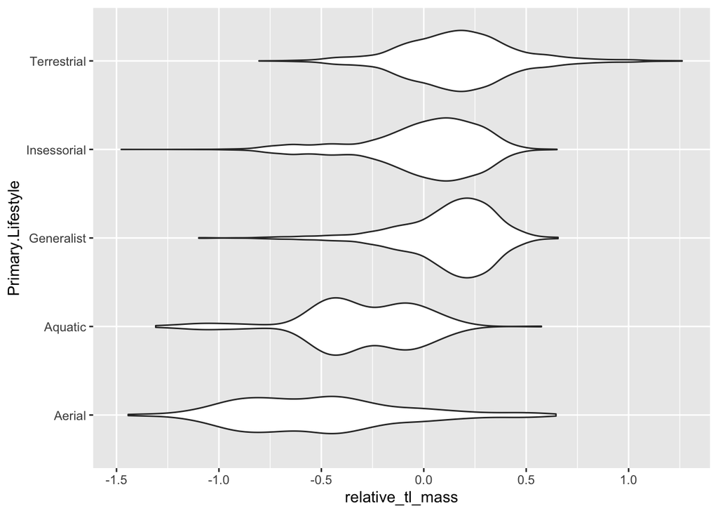

```r
# A: Tl_Mass residuals vs primary lifestyle
rel.tlm_pl <- ggplot(data = d1,  #tl= tarsus length, m = mass, res= residuals, pl = primary lifestyle
                   aes(x = relative_tl_mass, #the relative tarsus length (vs Mass)
                       y = Primary.Lifestyle # primary lifestyle (pl)
                       )
                   ) + geom_violin() # could also make it a box plot
rel.tlm_pl
```

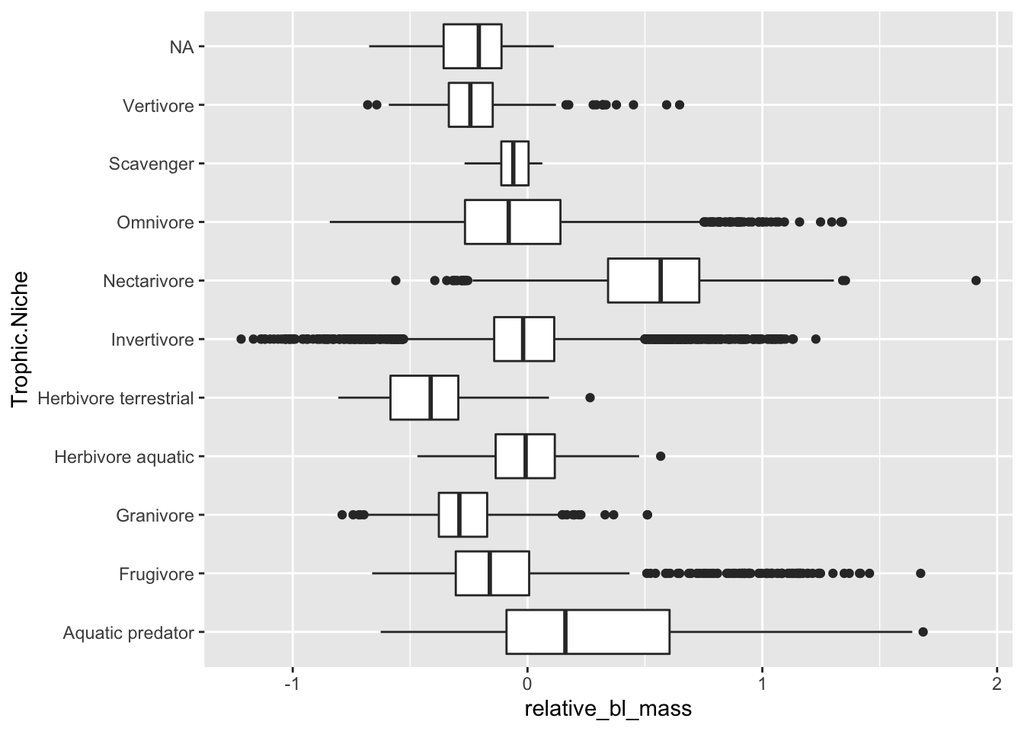

```r
# B: BL_Mass residuals vs trophic niche
rel.blm_tn <- ggplot(data = d1, #nl= beak length, m = mass, res= residuals, tn = trophic niche
                   aes(x = relative_bl_mass,#the relative beak length (vs Mass) (blm)
                       y = Trophic.Niche # trophic niche (tn)
                       )
                   ) + geom_boxplot() # could also make it a violin plot
rel.blm_tn
```

### Step 3

1. Run an ANOVA analyses to look at the association between geographic range size and the variable **Migration**. You should first look at the distribution of the variable **Range.Size** and decide whether and how it might need to be transformed.

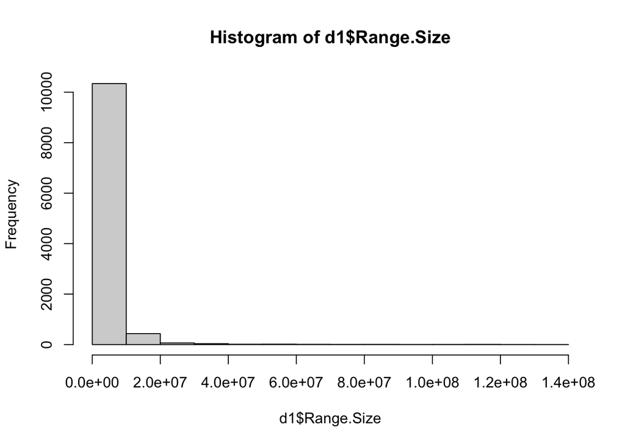

```r
#range size tranformation
hist(d1$Range.Size) #looks funky, thus log transformation
```

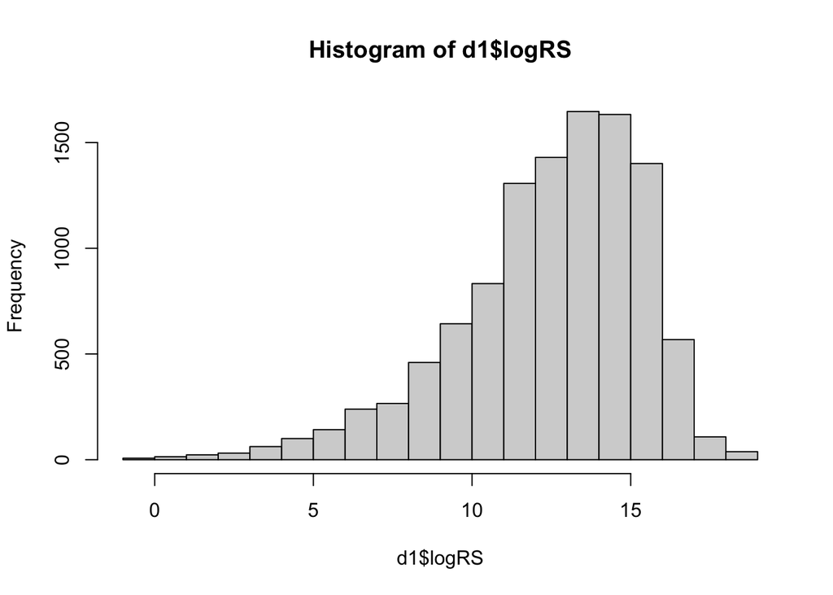

```r
# RS transformation
d1 <- d1 %>% mutate(logRS = log(Range.Size)) # making a new variable of log(range size) in dataset for ease
hist(d1$logRS) #much better.
```

```r
#migration status transformation
class(d1$Migration) # checking migration is numerical, but not actually numeric data
```

```
## [1] "numeric"
```

```r
# as.factor turns Migration into categorical data, and make a column for logMass
d1 <- mutate(d1, Migration = as.factor(Migration))
class(d1$Migration)# check migration now categorical/factor (could also use as.character())
```

```
## [1] "factor"
```

```r
#ANOVA
rs_m_a <- aov(data = d1, logRS ~ Migration) # rs = range size, m = migration
# rs_m_a <- tidy(rs_m_a)
summary(rs_m_a)
```

```
##                Df Sum Sq Mean Sq F value Pr(>F)
## Migration       2   8071    4035   520.3 <2e-16 ***
## Residuals   10934  84798       8
## ---
## Signif. codes:  0 '***' 0.001 '**' 0.01 '*' 0.05 '.' 0.1 ' ' 1
## 72 observations deleted due to missingness
```

```r
# the original ANOVA model for reference
summary(rs_m_a)
```

```
##                Df Sum Sq Mean Sq F value Pr(>F)
## Migration       2   8071    4035   520.3 <2e-16 ***
## Residuals   10934  84798       8
## ---
## Signif. codes:  0 '***' 0.001 '**' 0.01 '*' 0.05 '.' 0.1 ' ' 1
## 72 observations deleted due to missingness
```

```r
# We can easily relevel() what is the baseline group. The result is very similar, but the sign of  β1 is changed.
# the predictor variable, Migration, is a factor vector instead of a numeric vector, the coefficients are reported and interpreted a bit differently
levels(d1$Migration)
```

```
## [1] "1" "2" "3"
```

```r
# Relevel to reference level 1
d1 <- d1 %>% mutate(Migration = relevel(Migration, ref = "1"))
#re-run ANOVA with defined reference level 1
rs_m_a1 <- aov(data = d1, logRS ~ Migration)
summary(rs_m_a1)
```

```
##                Df Sum Sq Mean Sq F value Pr(>F)
## Migration       2   8071    4035   520.3 <2e-16 ***
## Residuals   10934  84798       8
## ---
## Signif. codes:  0 '***' 0.001 '**' 0.01 '*' 0.05 '.' 0.1 ' ' 1
## 72 observations deleted due to missingness
```

```r
# Relevel to reference level 2
d1 <- d1 %>% mutate(Migration = relevel(Migration, ref = "2"))
#re-run ANOVA with defined reference level 2
rs_m_a2 <- aov(data = d1, logRS ~ Migration)
summary(rs_m_a2)
```

```
##                Df Sum Sq Mean Sq F value Pr(>F)
## Migration       2   8071    4035   520.3 <2e-16 ***
## Residuals   10934  84798       8
## ---
## Signif. codes:  0 '***' 0.001 '**' 0.01 '*' 0.05 '.' 0.1 ' ' 1
## 72 observations deleted due to missingness
```

```r
# Relevel to reference level 3
d1 <- d1 %>% mutate(Migration = relevel(Migration, ref = "3"))
#re-run ANOVA with defined reference level 3
rs_m_a3 <- aov(data = d1, logRS ~ Migration)
summary(rs_m_a3)
```

```
##                Df Sum Sq Mean Sq F value Pr(>F)
## Migration       2   8071    4035   520.3 <2e-16 ***
## Residuals   10934  84798       8
## ---
## Signif. codes:  0 '***' 0.001 '**' 0.01 '*' 0.05 '.' 0.1 ' ' 1
## 72 observations deleted due to missingness
```

[B] Conduct a post-hoc **Tukey Significant Differences** test to also evaluate which **Migration** categories differ “significantly” from one another.  
(https://difiore.github.io/ada-2022/20-module.html#post-hoc-tests-in-anova).  
[NOTE: The `TukeyHSD()` function is run on the output of the ANOVA (`aov()`) function.]

```r
# running the tukey test on ANOVA of Range Size vs Migration
rs_m_a
```

```
## Call:
##    aov(formula = logRS ~ Migration, data = d1)
##
## Terms:
##                 Migration Residuals
## Sum of Squares    8070.57  84798.06
## Deg. of Freedom         2     10934
##
## Residual standard error: 2.78486
## Estimated effects may be unbalanced
## 72 observations deleted due to missingness
```

```r
#post-hoc test
posthoc_rs_m_a <- TukeyHSD(rs_m_a, which = "Migration", ordered = TRUE, conf.level = 0.95)
posthoc_rs_m_a # all levels of migration compared to each other
```

```
##   Tukey multiple comparisons of means
##     95% family-wise confidence level
##     factor levels have been ordered
##
## Fit: aov(formula = logRS ~ Migration, data = d1)
##
## $Migration
##          diff      lwr      upr p adj
## 2-1 1.7846901 1.582952 1.986428     0
## 3-1 2.5170168 2.297150 2.736883     0
## 3-2 0.7323266 0.450689 1.013964     0
```

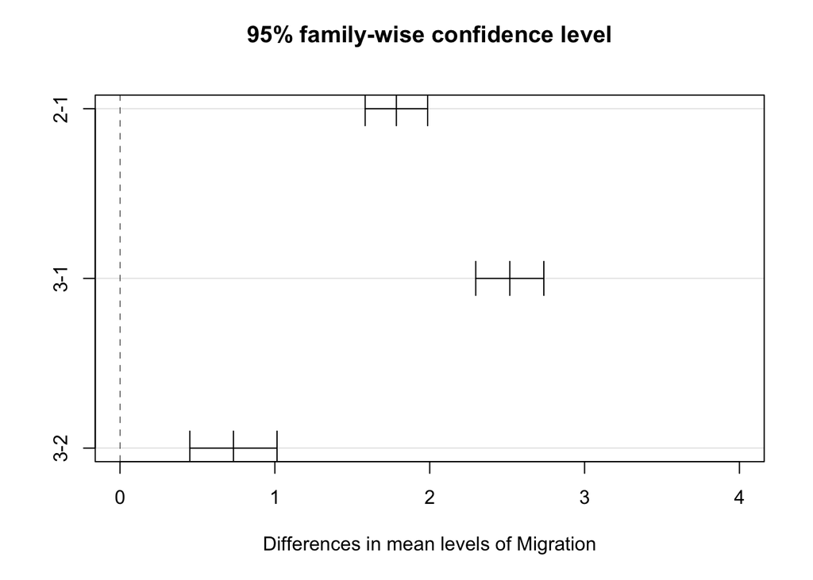

```r
# plotting the posthoc Tukey test for a nice visual summary
plot(posthoc_rs_m_a, xlim = c(0, 4)) # xlim set to show zero
```

### Step 4

1. Winnow your data to just consider birds from the Infraorder “Passeriformes” (song birds).

```r
passer <- d1 %>% filter(Order1 == "Passeriformes")
```

2. Run separate one-factor ANOVA analyses to look at the association between [1] **relative beak length** and **Primary.Lifestyle** and between [2] **relative beak length** and **Trophic.Level**. In doing so…  
   [A] Make boxplots of response variable by each predictor and by the combination of predictors  
   [B] Run linear models for each predictor separately and interpret the model output

```r
# 1. ANOVA of relative beak length and primary lifestyle of Passeriformes (.a = anova)
pass_rblm_pl.a <- aov(data = passer, relative_bl_mass ~ Primary.Lifestyle) # ANOVA, pass = Passeriformes, r = relative
summary(pass_rblm_pl.a)
```

```
##                     Df Sum Sq Mean Sq F value Pr(>F)
## Primary.Lifestyle    3   18.2   6.067   130.2 <2e-16 ***
## Residuals         6610  307.9   0.047
## ---
## Signif. codes:  0 '***' 0.001 '**' 0.01 '*' 0.05 '.' 0.1 ' ' 1
```

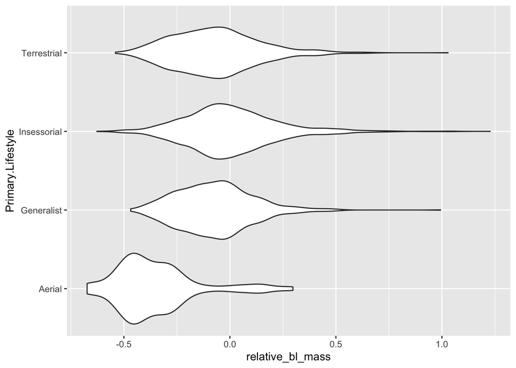

```r
# 1A Boxplot of relative beak length by primary lifestyle (.p = plot)
pass_rblm_pl.p <- ggplot(data = passer, # passer only filtered dataframe
                         aes(x = relative_bl_mass,# the relative beak length (vs Mass) (rblm)
                             y = Primary.Lifestyle # pl
                             )
                         ) + geom_violin()
pass_rblm_pl.p
```

```r
# 1B linear model: relative bleak length vs primary lifestyle of Passeriformes (.lm = linear model)
pass_rblm_pl.lm <- lm(data = passer, relative_bl_mass ~ Primary.Lifestyle)
summary(pass_rblm_pl.lm)
```

```
##
## Call:
## lm(formula = relative_bl_mass ~ Primary.Lifestyle, data = passer)
##
## Residuals:
##     Min      1Q  Median      3Q     Max
## -0.6314 -0.1380 -0.0172  0.1118  1.2241
##
## Coefficients:
##                              Estimate Std. Error t value Pr(>|t|)
## (Intercept)                  -0.34950    0.02158  -16.19   <2e-16 ***
## Primary.LifestyleGeneralist   0.27926    0.02306   12.11   <2e-16 ***
## Primary.LifestyleInsessorial  0.35342    0.02181   16.20   <2e-16 ***
## Primary.LifestyleTerrestrial  0.27924    0.02249   12.42   <2e-16 ***
## ---
## Signif. codes:  0 '***' 0.001 '**' 0.01 '*' 0.05 '.' 0.1 ' ' 1
##
## Residual standard error: 0.2158 on 6610 degrees of freedom
## Multiple R-squared:  0.05581,    Adjusted R-squared:  0.05538
## F-statistic: 130.2 on 3 and 6610 DF,  p-value: < 2.2e-16
```

```r
# 2 ANOVA of relative beak length and trophic level of Passeriformes (.a = anova)
pass_rblm_tl.a <- aov(data = passer, relative_bl_mass ~ Trophic.Level) # ANOVA, pass = Passeriformes, r = relative
summary(pass_rblm_tl.a)
```

```
##                 Df Sum Sq Mean Sq F value Pr(>F)
## Trophic.Level    2  16.31   8.154     174 <2e-16 ***
## Residuals     6611 309.81   0.047
## ---
## Signif. codes:  0 '***' 0.001 '**' 0.01 '*' 0.05 '.' 0.1 ' ' 1
```

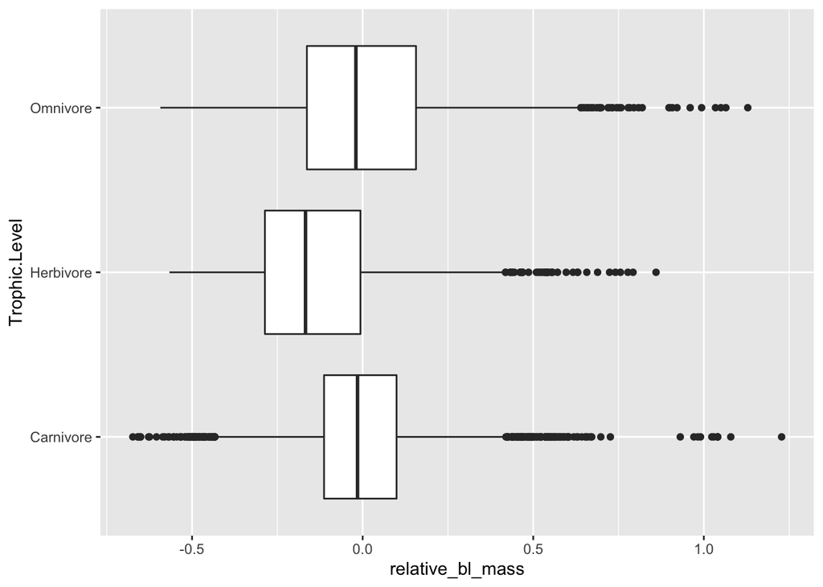

```r
# 2A Boxplot of relative beak length by trophic niche
pass_rblm_tl.p <- ggplot(data = passer,
                         aes(x = relative_bl_mass, # the relative beak length (vs Mass) (rblm)
                             y = Trophic.Level # the relative beak length (vs Mass) (rblm)
                             )
                         ) + geom_boxplot()
pass_rblm_tl.p
```

```r
# 2B linear model: relative beak length vs trophic level  of Passeriformes
pass_rblm_tl.lm <- lm(data = passer, relative_bl_mass ~ Trophic.Level)
summary(pass_rblm_tl.lm)
```

```
##
## Call:
## lm(formula = relative_bl_mass ~ Trophic.Level, data = passer)
##
## Residuals:
##      Min       1Q   Median       3Q      Max
## -0.67045 -0.13692 -0.02063  0.11129  1.23116
##
## Coefficients:
##                         Estimate Std. Error t value Pr(>|t|)
## (Intercept)            -0.003170   0.003501  -0.906  0.36518
## Trophic.LevelHerbivore -0.118713   0.006956 -17.066  < 2e-16 ***
## Trophic.LevelOmnivore   0.017902   0.006606   2.710  0.00675 **
## ---
## Signif. codes:  0 '***' 0.001 '**' 0.01 '*' 0.05 '.' 0.1 ' ' 1
##
## Residual standard error: 0.2165 on 6611 degrees of freedom
## Multiple R-squared:  0.05001,    Adjusted R-squared:  0.04972
## F-statistic:   174 on 2 and 6611 DF,  p-value: < 2.2e-16
```

### Step 5

Run a two-factor model to look at the association between **relative beak length** and both **Primary.Lifestyle** and **Trophic.Level** among passeriforms.

```r
pass_rblm_pl_tl <- aov(data = passer, relative_bl_mass ~ Primary.Lifestyle + Trophic.Level)
summary(pass_rblm_pl_tl)
```

```
##                     Df Sum Sq Mean Sq F value Pr(>F)
## Primary.Lifestyle    3  18.20   6.067   138.1 <2e-16 ***
## Trophic.Level        2  17.68   8.838   201.2 <2e-16 ***
## Residuals         6608 290.24   0.044
## ---
## Signif. codes:  0 '***' 0.001 '**' 0.01 '*' 0.05 '.' 0.1 ' ' 1
```

**Q:** Based on the model output, what would you conclude about how relative beak length is related to these two variables?  
**A:** I conclude there is a significant association between relative beak length and trophic level and primary lifestyle as individual variables.

### Step 6

Finally, run an additional two-way model with the same dataset and predictors, but adding the possibility of an interaction term. To do this, you should modify your model formula using the colon operator (`:`) to specify the interaction, e.g., **relative beak length ~ Primary.Lifestyle + Trophic.Level + Primary.Lifestyle:Trophic.Level**.

```r
pass_rblm_pl_tl.i <- aov(data = passer, relative_bl_mass ~ Primary.Lifestyle + Trophic.Level + Primary.Lifestyle:Trophic.Level) # .i = interaction
summary(pass_rblm_pl_tl.i)
```

```
##                                   Df Sum Sq Mean Sq F value Pr(>F)
## Primary.Lifestyle                  3  18.20   6.067  142.15 <2e-16 ***
## Trophic.Level                      2  17.68   8.838  207.11 <2e-16 ***
## Primary.Lifestyle:Trophic.Level    4   8.41   2.102   49.26 <2e-16 ***
## Residuals                       6604 281.83   0.043
## ---
## Signif. codes:  0 '***' 0.001 '**' 0.01 '*' 0.05 '.' 0.1 ' ' 1
```

**Q:**Based on the model output, what would you now conclude about how relative beak length is related to these two variables?  
**A:** I conclude there is a significant association between relative beak length and trophic level and primary lifestyle as independent variables AND when they intersect with each other.

### Step 7

Use the `interaction.plot()` function to visualize the interaction between **Primary.Lifestyle** and **Trophic.Level** (see Module 20).

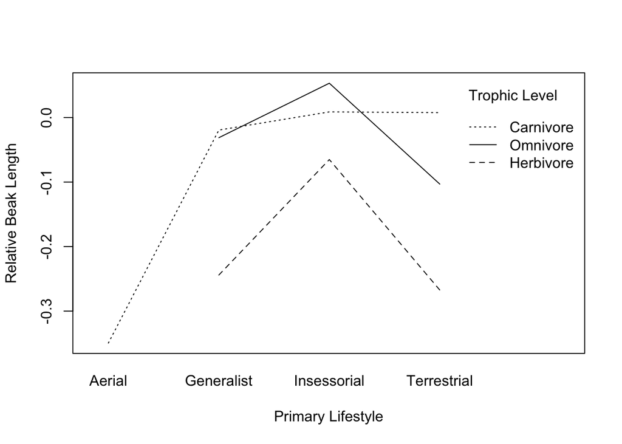

```r
interaction.plot(
  x.factor = passer$Primary.Lifestyle, # predictor 1
  xlab = "Primary Lifestyle",
  trace.factor = passer$Trophic.Level, # predictor 2
  trace.label = "Trophic Level",
  response = passer$relative_bl_mass, # response variable is relative beak length
  fun = base::mean, # make sure we use {base} version
  ylab = "Relative Beak Length"
)
```

### Additional Steps?

As noted in Module 20, a general rule of thumb for “equal” variances is to compare the largest and smallest within-grouping level standard deviations and, if this value is less than 2, then it is often reasonable to presume the assumption may not be violated. As a an additional step, check whether **relative beak length** is normally distributed across **Trophical.Level** groups and whether the variance in relative beak size is or is not roughly the same across levels.

```r
# rel.blm_tl_hist <- ggplot(data = NULL, aes(x = BL_Mass$model$logBL, y = BL_Mass$residuals)) + geom_point() + facet_wrap(d1$Trophic.Level)
# rel.blm_tl_hist

#rel.blm_tl_hist <- ggplot(data = d1, aes(x = relative_bl_mass)) + geom_histogram() + facet_wrap(d1$Trophic.Level)
#rel.blm_tl_hist
# plot the residuals of beak length and Mass (linear model that gave the relative beak length residuals)
# plot(BL_Mass) # ~ d1$Trophic.Level
```

i tried my best and did not succeed, just as coldplay foretold.

the end of challenge 2.